# 06 KSNVE - Hands on Practice

**Hands-on Practice**

|  | by Prof. Seungchul Lee iSystems Design Lab http://isystems.unist.ac.kr/ UNIST |
| --- | --- |

Table of Contents

```python
import seaborn as sns; sns.set(style="ticks", color_codes=True)
```

# 1. Data Load

- cPickle을 이용하여 데이터 로드
- 예제 데이터는 아래 링크를 통해 받을 수 있습니다.
  - rotation_data.pkl

```python
from six.moves import cPickle
```

```python
data = cPickle.load(open('./data_files/rotation_data.pkl', 'rb'))
```

- Data 구조 파악 (Dictionary로 저장해 둔 데이터)

```python
print(data.keys())
```

```
dict_keys(['rubbing', 'unbal', 'misalign', 'normal'])
```

```python
(X1, y1) = data['misalign']
(X2, y2) = data['unbal']
(X3, y3) = data['normal']
(X4, y4) = data['rubbing']
```

```python
X1.shape
```

```
(300, 820)
```

- Plot 으로 확인하기

```python
import matplotlib.pyplot as plt
```

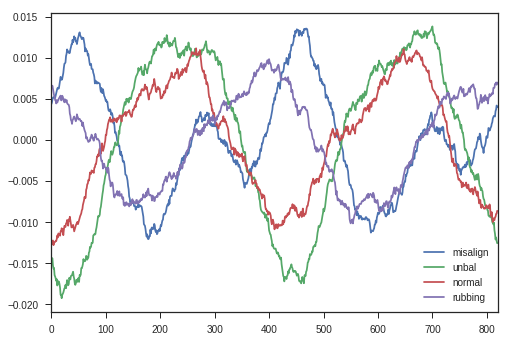

```python
for data_type in ['misalign', 'unbal', 'normal', 'rubbing']:
    X, y = data[data_type]
    plt.plot(X[10,:], label=data_type)
plt.legend(loc = 'lower right')
plt.xlim(0,X1.shape[1])
plt.show()
```

# 2. Preprocess

- 편의를 위하여 데이터를 하나로 병합하기

```python
import numpy as np
```

```python
X = np.vstack([X1, X2, X3, X4])
y = np.concatenate([y1, y2, y3, y4])
```

- 평균을 0으로 맞추기
- 표준편차를 1로 맞추기
- sklearn.preprocessing 에 StandardScaler 이용

```python
from sklearn.preprocessing import StandardScaler
```

```python
sdc = StandardScaler()
X = sdc.fit_transform(X)
```

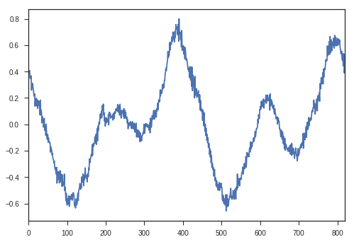

```python
plt.plot(X[100,:])
plt.xlim(0,X.shape[1])
plt.show()
```

- PCA를 이용하여 feature 추출하기
- 2차원으로 차원 축소
- sklearn.decomposition 에 PCA 이용

```python
from sklearn.decomposition import PCA
```

```python
pca = PCA(n_components=2)
X_pca = pca.fit_transform(X)
```

```python
print(X_pca.shape)
```

```
(1350, 2)
```

```python
pca.explained_variance_ratio_
```

```
array([ 0.11915963,  0.11747344])
```

- 차원 축소 결과 확인

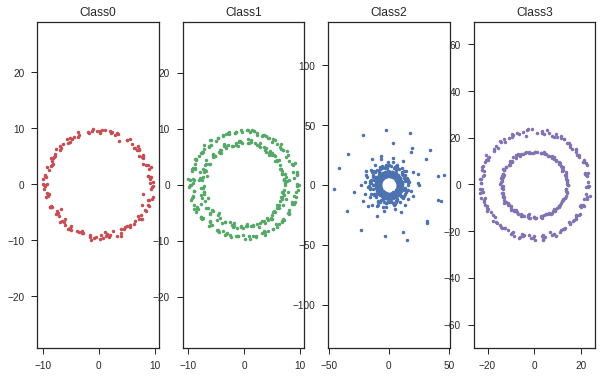

```python
fig = plt.figure(figsize=(10,6))
color = ['r.', 'g.', 'b.', 'm.']
for i in range(4):
    ax = fig.add_subplot(1, 4, i+1, title='Class'+str(i))
    ax.plot(X_pca[y==i, 0], X_pca[y==i, 1], color[i])
    plt.axis('equal')
plt.show()
```

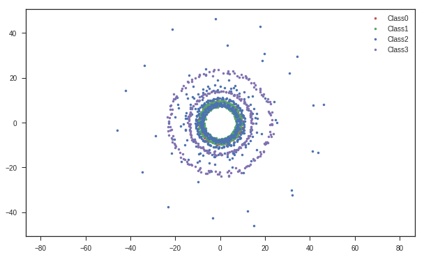

```python
fig = plt.figure(figsize=(10,6))
color = ['r.', 'g.', 'b.', 'm.']
for i in range(4):
    plt.plot(X_pca[y==i, 0], X_pca[y==i, 1], color[i], label='Class'+str(i))
    plt.axis('equal')
plt.legend()
plt.show()
```

# 3. Data Split

- Training data와 validation data로 나누기
- sklearn.cross_validation에 StratifiedKFold 이용

```python
from sklearn.cross_validation import StratifiedKFold
```

```python
skf = StratifiedKFold(y, n_folds=5)
```

```python
train_indices, valid_indices = next(iter(skf))
X_train, y_train = X_pca[train_indices, :], y[train_indices]
X_valid, y_valid = X_pca[valid_indices, :], y[valid_indices]
```

**RNN의 경우 label 을 다르게 하는 것이 편리하다**

- From
  - y = 1, ... , 4
- To
  - y = [1, 0, 0, 0], ... , [0, 0, 0, 1]
- sklearn.preprocessing에 OneHotEncoder 이용

```python
from sklearn.preprocessing import OneHotEncoder
```

```python
# n_values sets number of classes
ohe = OneHotEncoder(n_values = 4)
y_to_ohg = y.reshape(-1, 1)
ohe.fit(y_to_ohg) # X1 is defined in LabelEncoder part
y_ohe = ohe.transform(y_to_ohg) # transform gives scipy.sparse type output
y_ohe = y_ohe.toarray()
```

- RNN을 위한 X, y의 경우 끝에 _rnn을 붙임
  - X의 경우 차원 축소 되기 전 (PCA 적용 전 X)

```python
X_train_rnn, y_train_rnn = X[train_indices, :], y_ohe[train_indices]
X_valid_rnn, y_valid_rnn = X[valid_indices, :], y_ohe[valid_indices]
```

```python
X_train_rnn.shape
```

```
(1080, 820)
```

```python
y_train_rnn.shape
```

```
(1080, 4)
```

# 4. Classification

- Logistic Regression
- Linear SVM
- Nonlinear SVM
- Recurrent Neural NetworK

## 4.1. Logistic Regression

- Logistic Regression 모듈 import

```python
from sklearn.linear_model import LogisticRegression
```

```python
clf = LogisticRegression(C=1.0)
clf.fit(X_train, y_train)
```

```
LogisticRegression(C=1.0, class_weight=None, dual=False, fit_intercept=True,
          intercept_scaling=1, max_iter=100, multi_class='ovr', n_jobs=1,
          penalty='l2', random_state=None, solver='liblinear', tol=0.0001,
          verbose=0, warm_start=False)
```

- Validation set 으로 성능 확인

```python
pred = clf.predict(X_valid)
accuracy = np.mean(np.equal(pred, y_valid))
print('Accuracy = {:.4f}'.format(accuracy))
```

```
Accuracy = 0.4444
```

## 4.2. Linear SVM

- SVC 모듈 import

```python
from sklearn.svm import SVC
```

```python
clf = SVC(kernel='linear', C=1.0)
clf.fit(X_train, y_train)
```

```
SVC(C=1.0, cache_size=200, class_weight=None, coef0=0.0,
  decision_function_shape=None, degree=3, gamma='auto', kernel='linear',
  max_iter=-1, probability=False, random_state=None, shrinking=True,
  tol=0.001, verbose=False)
```

- Validatioin set 으로 성능 확인

```python
pred = clf.predict(X_valid)
accuracy = np.mean(np.equal(pred, y_valid))
print('Accuracy = {:.4f}'.format(accuracy))
```

```
Accuracy = 0.4444
```

## 4.3. Nonlinear SVM

- SVC 모듈 import

```python
from sklearn.svm import SVC
```

```python
clf = SVC(kernel='rbf', C=1.0)
clf.fit(X_train,  y_train)
```

```
SVC(C=1.0, cache_size=200, class_weight=None, coef0=0.0,
  decision_function_shape=None, degree=3, gamma='auto', kernel='rbf',
  max_iter=-1, probability=False, random_state=None, shrinking=True,
  tol=0.001, verbose=False)
```

- Validation set 으로 성능 확인

```python
pred = clf.predict(X_valid)
accuracy = np.mean(np.equal(pred, y_valid))
print('Accuracy = {:.4f}'.format(accuracy))
```

```
Accuracy = 0.6407
```

```python
svc = SVC(kernel='linear', C=1).fit(X_pca, y)
rbf_svc = SVC(kernel='rbf', C=1, gamma=1).fit(X_pca, y)
```

```python
# create a mesh to plot in
h = 1  # step size in the mesh
x_min, x_max = X_pca[:, 0].min() - 1, X_pca[:, 0].max() + 1
y_min, y_max = X_pca[:, 1].min() - 1, X_pca[:, 1].max() + 1
xx, yy = np.meshgrid(np.arange(x_min, x_max, h),
                     np.arange(y_min, y_max, h))
```

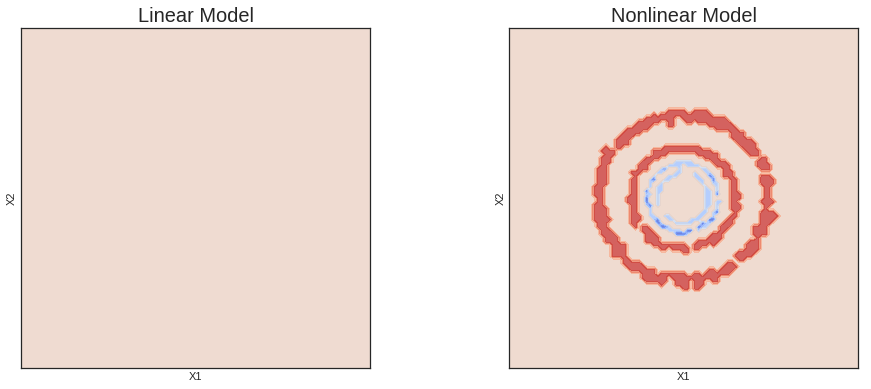

```python
# title for the plots
titles = ['Linear Model', 'Nonlinear Model']

fig = plt.figure(figsize=(15,15))
for i, clf in enumerate((svc, rbf_svc)):
    plt.subplot(2, 2, i + 1)
    plt.subplots_adjust(wspace=0.4, hspace=0.4)

    Z = clf.predict(np.c_[xx.ravel(), yy.ravel()])

    # Put the result into a color plot
    Z = Z.reshape(xx.shape)
    plt.contourf(xx, yy, Z, cmap=plt.cm.coolwarm, alpha=0.8)

    # Plot also the training points
    # plt.scatter(X[:, 0], X[:, 1], c=y, cmap=plt.cm.coolwarm)
    plt.xlabel('X1')
    plt.ylabel('X2')
    plt.xlim(xx.min(), xx.max())
    plt.ylim(yy.min(), yy.max())
    plt.xticks(())
    plt.yticks(())
    plt.title(titles[i], fontsize=20)

plt.show()
```

## 4.4. Recurrent Neural Network

```python
import tensorflow as tf
```

- Define Variable

```python
'''
batch size
learning rate
n_iter
flag
등 학습과정에서 필요할 variable 정의
'''
learning_rate = 0.5
n_iter = 5000
flag = 500
```

- Define Network Size
  - input data의 shape 확인

```python
'''
total length
input sequence
input steps
hidden layer 개수
등 네트워크를 구성하는데 직접적인 영향을 주는 variable정의
'''
total_length = 820
n_steps = 10
n_input_sequence = int(total_length//n_steps)
n_hidden = 30
n_classes = 4
```

- Define Weights

```python
'''
Network 안에 들어갈 weigth, biases 정의
'''

weights = {
    'out' : tf.Variable(tf.random_normal([n_hidden, n_classes], stddev = 0.1))
}

biases = {
    'out' : tf.Variable(tf.random_normal([n_classes], stddev = 0.1))
}
```

- Define Network

```python
def RNN(x, weights, biases, n_input, n_step, batch_size):
    x = tf.transpose(x, [1, 0, 2])
    x = tf.reshape(x, [-1, n_input])
    x = tf.split(x, n_step, 0)

    with tf.variable_scope('rnn') as scope :
        lstm_cell = tf.contrib.rnn.BasicLSTMCell(n_hidden, forget_bias=1.0, state_is_tuple=True)
        ch_tuple = lstm_cell.zero_state(batch_size, dtype=tf.float32)

        c_list = []
        h_list = []

        for input_ in x:
            try :
                h, ch_tuple = lstm_cell(input_, ch_tuple)
            except ValueError :
                scope.reuse_variables()
                h, ch_tuple = lstm_cell(input_, ch_tuple)

            c_list.append(ch_tuple[0])
            h_list.append(ch_tuple[1])

    return tf.matmul(h_list[-1], weights['out']) + biases['out']
```

- Define Cost

```python
x = tf.placeholder(tf.float32, [None, n_steps, n_input_sequence])
y = tf.placeholder(tf.float32, [None, n_classes])

Batch_size_place_holder = tf.placeholder(tf.int32)
RNN_result = RNN(x, weights, biases, n_input_sequence, n_steps, Batch_size_place_holder)

cost = tf.reduce_mean(tf.square(RNN_result - y))
optimizer = tf.train.GradientDescentOptimizer(learning_rate).minimize(cost)
```

- Optimize

```python
X_train_rnn.shape
```

```
(1080, 820)
```

```python
# Optimize
init = tf.global_variables_initializer()
sess = tf.Session()

sess.run(init)

# Training cycle
for epoch in range(n_iter):
    X_train_reshape = np.reshape(X_train_rnn, [-1, n_steps, n_input_sequence])
    sess.run(optimizer, feed_dict={x: X_train_reshape, y: y_train_rnn, Batch_size_place_holder: X_train_reshape.shape[0]})
    c = sess.run(cost, feed_dict={x: X_train_reshape,  y: y_train_rnn, Batch_size_place_holder: X_train_reshape.shape[0]})
    if epoch % flag == 0:
        print ("Iter : {}".format(epoch))
        print ("Cost : {}".format(c))
```

```
Iter : 0
Cost : 0.1960446685552597
Iter : 500
Cost : 0.053301259875297546
Iter : 1000
Cost : 0.04368560016155243
Iter : 1500
Cost : 0.041778355836868286
Iter : 2000
Cost : 0.0406017079949379
Iter : 2500
Cost : 0.03429705649614334
Iter : 3000
Cost : 0.02543618343770504
Iter : 3500
Cost : 0.0201957356184721
Iter : 4000
Cost : 0.015899494290351868
Iter : 4500
Cost : 0.013636562041938305
```

- Validatioin set 으로 성능 확인

```python
X_valid_reshape = np.reshape(X_valid_rnn, [-1, n_steps, n_input_sequence])
pred = sess.run(RNN_result, feed_dict={x:X_valid_reshape, Batch_size_place_holder: X_valid_reshape.shape[0]})
accuracy = np.mean(np.equal(np.argmax(pred, 1), np.argmax(y_valid_rnn, 1)))
print('Accuracy = {:.4f}'.format(accuracy))
```

```
Accuracy = 0.9889
```

```python
%%javascript
$.getScript('https://kmahelona.github.io/ipython_notebook_goodies/ipython_notebook_toc.js')
```